# Statistical Learning Project

## Project 1: Stastical Learning Project

### Domain: Healthcare

### Context:

Leveraging customer information is paramount for most businesses. In the case of an insurance company, attributes of customers like the ones mentioned below can be crucial in making business decisions. Hence, knowing to explore and generate value out of such data can be an invaluable skill to have.

### Question 1: Import the necessary libraries

```python
%matplotlib inline
```

```python
#Import necessary libraries
import pandas as pd
import numpy as np
from matplotlib import pyplot as plt
import seaborn as sns
from scipy.stats import skew
from scipy.stats import norm
from scipy import stats
from scipy.stats import ttest_1samp, ttest_ind, mannwhitneyu, levene, shapiro
from statsmodels.stats.power import ttest_power
```

### Question 1: Read the data as data frame

```python
#read u.data file from the folder and name the columns after referring to the Readme file in the same folder
insurance_data = pd.read_csv('insurance.csv')
insurance_data.head()
```

|  | age | sex | bmi | children | smoker | region | charges |
| --- | --- | --- | --- | --- | --- | --- | --- |
| 0 | 19 | female | 27.900 | 0 | yes | southwest | 16884.92400 |
| 1 | 18 | male | 33.770 | 1 | no | southeast | 1725.55230 |
| 2 | 28 | male | 33.000 | 3 | no | southeast | 4449.46200 |
| 3 | 33 | male | 22.705 | 0 | no | northwest | 21984.47061 |
| 4 | 32 | male | 28.880 | 0 | no | northwest | 3866.85520 |

### Question 2: EDA - shape & type of Data

```python
insurance_data.shape
```

```
(1338, 7)
```

#### Dataset consists of 1338 rows and 7 columns (features)

```python
insurance_data.dtypes
```

```
age           int64
sex          object
bmi         float64
children      int64
smoker       object
region       object
charges     float64
dtype: object
```

```python
## Numeric columns
numeric_cols = []
for col in insurance_data.columns:
    if (insurance_data[col].dtype == 'float64' or insurance_data[col].dtype=='int64'):
        numeric_cols.append(col)
numeric_cols
```

```
['age', 'bmi', 'children', 'charges']
```

### Question 3: EDA - Checking the presence of missing values

```python
insurance_data.info()
```

```
<class 'pandas.core.frame.DataFrame'>
RangeIndex: 1338 entries, 0 to 1337
Data columns (total 7 columns):
 #   Column    Non-Null Count  Dtype
---  ------    --------------  -----
 0   age       1338 non-null   int64
 1   sex       1338 non-null   object
 2   bmi       1338 non-null   float64
 3   children  1338 non-null   int64
 4   smoker    1338 non-null   object
 5   region    1338 non-null   object
 6   charges   1338 non-null   float64
dtypes: float64(2), int64(2), object(3)
memory usage: 73.3+ KB
```

```python
insurance_data.isnull().sum()
```

```
age         0
sex         0
bmi         0
children    0
smoker      0
region      0
charges     0
dtype: int64
```

### This dataset does not have any missing vales. If missing values exits then

### we can also use heatmap to see patterns of missing value distributions

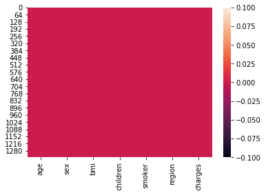

```python
sns.heatmap(insurance_data.isnull())
```

### Question 3: EDA - 5 point summary of numerical attributes

### Here we use describe function to get the required results

### This includes: count, mean, median, min, max and percentile of each numeric column in the dataset

```python
insurance_data.describe()
```

|  | age | bmi | children | charges |
| --- | --- | --- | --- | --- |
| count | 1338.000000 | 1338.000000 | 1338.000000 | 1338.000000 |
| mean | 39.207025 | 30.663397 | 1.094918 | 13270.422265 |
| std | 14.049960 | 6.098187 | 1.205493 | 12110.011237 |
| min | 18.000000 | 15.960000 | 0.000000 | 1121.873900 |
| 25% | 27.000000 | 26.296250 | 0.000000 | 4740.287150 |
| 50% | 39.000000 | 30.400000 | 1.000000 | 9382.033000 |
| 75% | 51.000000 | 34.693750 | 2.000000 | 16639.912515 |
| max | 64.000000 | 53.130000 | 5.000000 | 63770.428010 |

### Question 4: EDA - Distribution of ‘bmi’, ‘age’ and ‘charges’ columns

### We can use seaborn distplot plot to view univariate distribution of observations

### The distplot() function also shows kde with histogram.

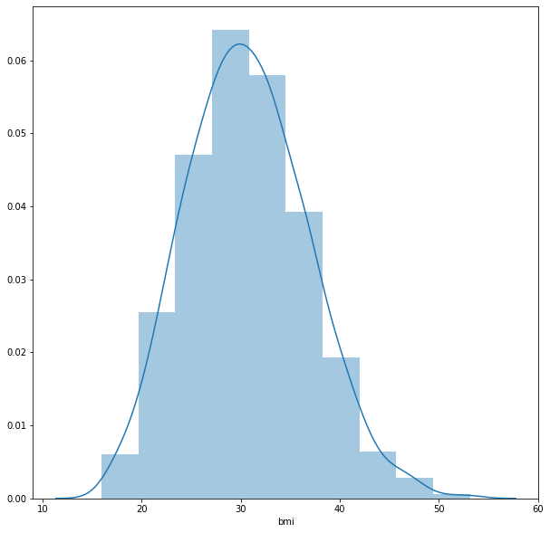

```python
plt.figure(figsize=(10,10))
sns.distplot(insurance_data['bmi'],bins=10);
```

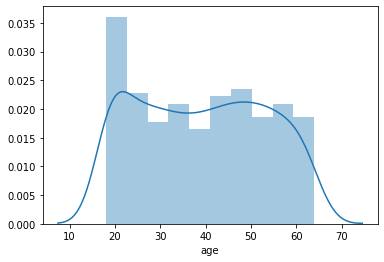

```python
sns.distplot(insurance_data['age'],bins=10)
```

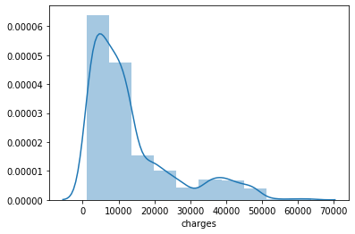

```python
sns.distplot(insurance_data['charges'],bins=10)
```

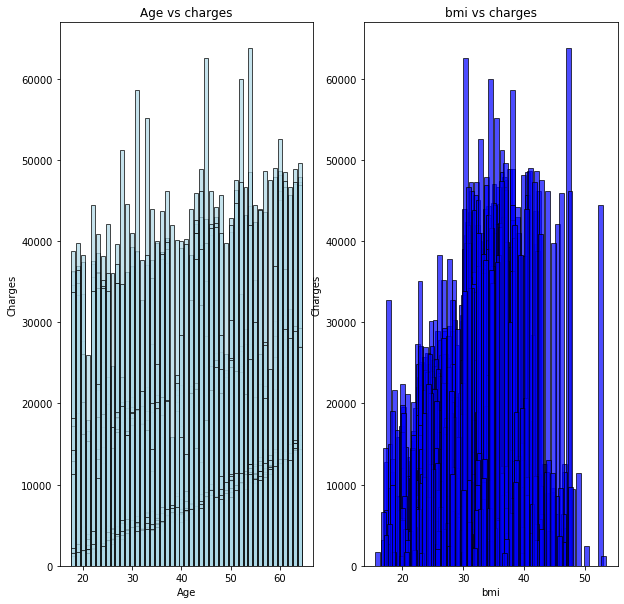

```python
# Bar chart to view distribution of charges accross all ages and bmi
x = insurance_data.age    #Values for x-axis
y = insurance_data['charges']   #count on y-axis
#plt.figure(figsize=(20,10))
fig,(ax1,ax2) = plt.subplots(1,2, figsize=(10,10));

ax1.bar(x,y, align='center',color = 'lightblue',edgecolor = 'black', alpha = 0.7);  #plot a bar chart
ax1.set(xlabel='Age', ylabel='Charges')
ax1.set_title('Age vs charges')
ax2.bar(insurance_data.bmi,insurance_data.charges, align='center',color = 'blue',edgecolor = 'black', alpha = 0.7)  #plot a bar chart
ax2.set(xlabel='bmi', ylabel='Charges')
ax2.set_title('bmi vs charges')
plt.show();
```

### Question 5: EDA - Measure of skewness of ‘bmi’, ‘age’ and ‘charges’ columns

### We can observe the skewness using density distribution and using probaility plot

### We can compute skewness using stats.skew () function

### Density plots and probability plots shows that charges column is skewed and skew() function shows it is positively skewed with the value of 1.515

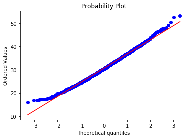

```python
res = stats.probplot(insurance_data['bmi'], plot=plt)
```

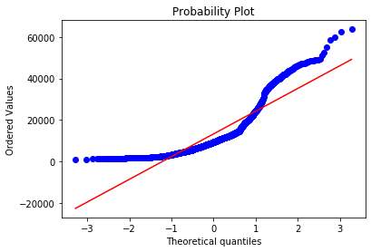

```python
res = stats.probplot(insurance_data['charges'], plot=plt)
```

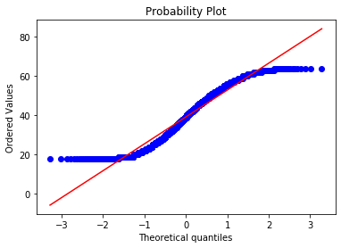

```python
res = stats.probplot(insurance_data['age'], plot=plt)
```

```python
#skewness
print("Skewness of bmi: %f" % insurance_data['bmi'].skew())
print("Skewness of age: %f" % insurance_data['age'].skew())
print("Skewness of charges: %f" % insurance_data['charges'].skew())
```

```
Skewness of bmi: 0.284047
Skewness of age: 0.055673
Skewness of charges: 1.515880
```

Skewness for charges is more as we can observe from distribution also and it is positive with value of 1.515 observed using skew() function.

### Question 6: EDA - Checking the presence of outliers in ‘bmi’, ‘age’ and ‘charges columns

### boxplots for ‘bmi’, ‘age’ and ‘charges’ columns

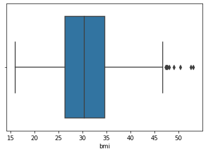

```python
sns.boxplot(insurance_data["bmi"])
plt.show()
```

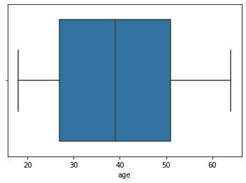

```python
sns.boxplot(insurance_data["age"])
plt.show()
```

### boxplot of charges column shows outliers . Also boxplot of bmi shows few outliers in the data.

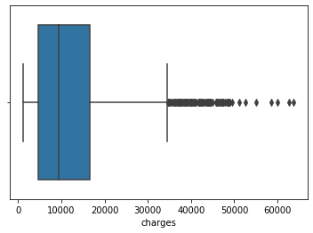

```python
sns.boxplot(insurance_data["charges"])
plt.show()
```

### boxplot can be plot for multiple variables to see the distribution. e.g. how charges feature is distributed

### based on gender, number of children, charges feature distribution based on gender etc.

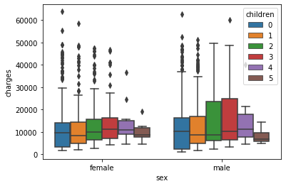

```python
sns.boxplot(y=insurance_data["charges"],x=insurance_data["sex"],hue=insurance_data["children"] )
plt.show();
```

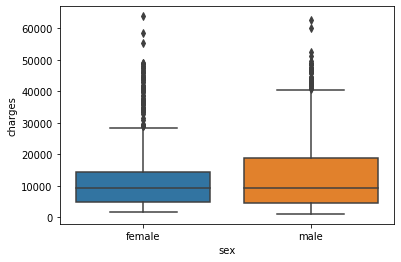

```python
sns.boxplot(y=insurance_data["charges"],x=insurance_data["sex"] )
plt.show();
```

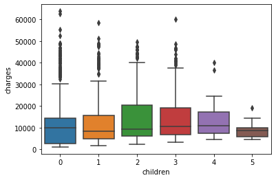

```python
sns.boxplot(y=insurance_data["charges"],x=insurance_data["children"] )
plt.show();
```

### Question 7: EDA - Distribution of categorical columns

```python
cat_cols = []
for col in insurance_data.columns:
    if (insurance_data[col].dtype == 'object'):
            cat_cols.append(col)
cat_cols
```

```
['sex', 'smoker', 'region']
```

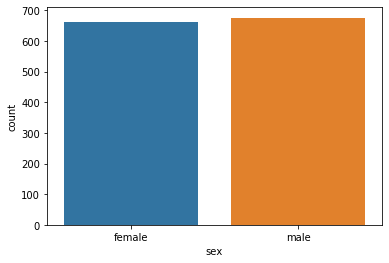

```python
sns.countplot(insurance_data['sex'])
plt.show();
```

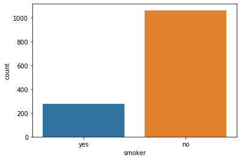

```python
sns.countplot(insurance_data['smoker'])
plt.show();
```

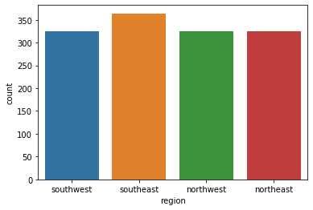

```python
sns.countplot(insurance_data['region'])
plt.show();
```

```
[]
```

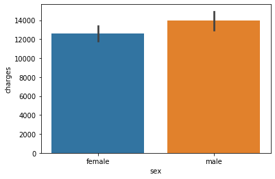

```python
sns.barplot(x=insurance_data['sex'], y=insurance_data['charges']);
plt.plot()
```

```
[]
```

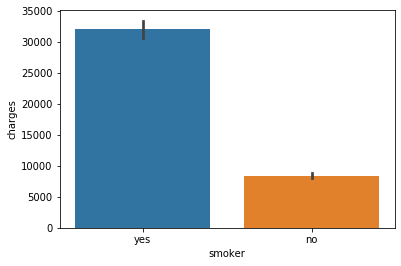

```python
sns.barplot(x=insurance_data['smoker'], y=insurance_data['charges']);
plt.plot()
```

```
[]
```

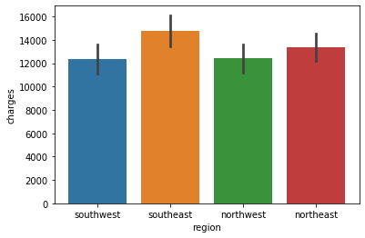

```python
sns.barplot(x=insurance_data['region'], y=insurance_data['charges']);
plt.plot()
```

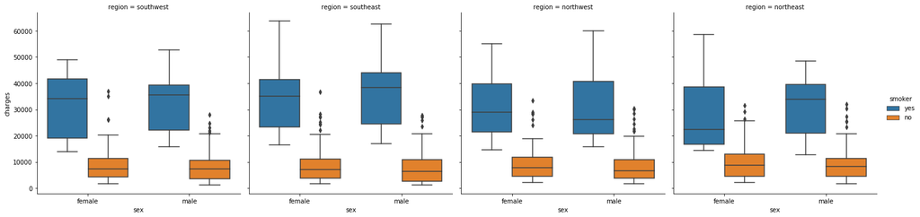

```python
sns.catplot(x="sex",
               y = "charges",
               hue="smoker",
               col = "region",
               data=insurance_data,
               kind="box");
```

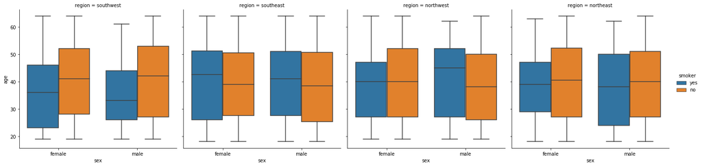

```python
sns.catplot(x="sex",
               y = "age",
               hue="smoker",
               col = "region",
               data=insurance_data,
               kind="box");
```

### Question 8: EDA - Pair plot that includes all the columns of the data frame

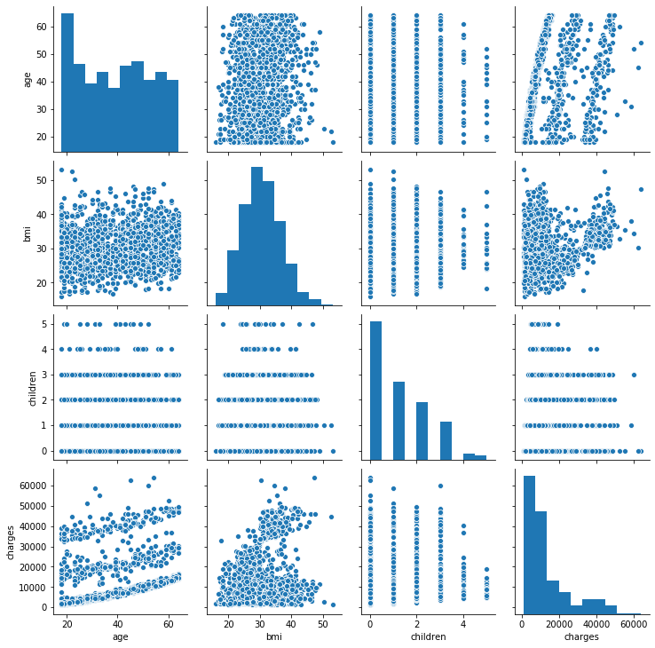

```python
sns.pairplot(insurance_data)
```

### Question 9: Do charges of people who smoke differ significantly from the people who don't?

### If average charges of smokers and non-smokers is compared, it shows significant difference.

### For non-smokers average charges are 8434 and for smokers average charges are 32050.

### We will do two-sample t test on the two samples to test if the means are same or differ significantly.

### First choose 30 samples each from smoker and non-smoker data.

### From the test, it shows there is significant difference between the charges of smokers and non-smokers.

```python
count_smokers = sum(insurance_data['smoker'] =="yes")
count_nonsmokers = sum(insurance_data['smoker'] =="no")
print("smoker and non-smoker counts", count_smokers,count_nonsmokers)
smoker_counts = insurance_data.groupby('smoker').sum()['charges'].sort_values(ascending = False)
print(smoker_counts)
```

```
smoker and non-smoker counts 274 1064
smoker
no     8.974061e+06
yes    8.781764e+06
Name: charges, dtype: float64
```

```python
smoker_data = insurance_data[insurance_data.smoker=="yes"]
smoker_data
smoker_data.charges.describe()
```

```
count      274.000000
mean     32050.231832
std      11541.547176
min      12829.455100
25%      20826.244213
50%      34456.348450
75%      41019.207275
max      63770.428010
Name: charges, dtype: float64
```

```python
nonsmoker_data = insurance_data[insurance_data.smoker=="no"]
nonsmoker_data
nonsmoker_data.charges.describe()
```

```
count     1064.000000
mean      8434.268298
std       5993.781819
min       1121.873900
25%       3986.438700
50%       7345.405300
75%      11362.887050
max      36910.608030
Name: charges, dtype: float64
```

### We choose random 30 samples from non-smoker and smoker data

### n1 = number of samples for non-smokers = 30

### n2 = number of samples for smokers = 30

### mean1 = mean charges of non-smokers = 6578.0

### mean2 = mean charges of smokers = 31930.0

### we perform two sample t-test

```python
subset_nonsmoker = nonsmoker_data.sample(n=30)
subset_smoker = smoker_data.sample(n=30)
```

```python
subset_nonsmoker.charges.describe()
```

```
count       30.000000
mean      6578.204058
std       4451.383588
min       1137.469700
25%       2447.929487
50%       5714.005800
75%      10561.045538
max      14349.854400
Name: charges, dtype: float64
```

```python
subset_smoker.charges.describe()
```

```
count       30.000000
mean     31930.406313
std      10816.245689
min      17081.080000
25%      21360.592425
50%      33604.251925
75%      41515.616175
max      47928.030000
Name: charges, dtype: float64
```

```python
t_statistic, p_value = ttest_ind(subset_smoker.charges, subset_nonsmoker.charges)
print(t_statistic, p_value)
```

```
11.871996693635813 3.685217632716602e-17
```

```python
print("p-value < 0.05 So the difference between charges to smokers and non-smokers is significant")
```

```
p-value < 0.05 So the difference between charges to smokers and non-smokers is significant
```

### Question 10: Does bmi of males differ significantly from that of females

### Perform hypothesis test: independent two sample t-test

### 1. Choose 30 samples each ranmomly from male and female population for bmi

### 2. Define hypothesis

### H0: two populations mean for bmi does not differ

### H1: the two population means are different

### This is two sample t-test

### 3. Do the two sample t-test on the sample data

### 4. Compare p-value with 0.05 for 95 % confidence

### 5. Reach one of the following conclusion: Reject the original position in favor of alternate position or fail to reject the initial position.